# RESEARCH

- Show All Code
- Hide All Code
- View Source

Impact of Smoking bans on mortality Rates: A Difference-in-Difference Analysis

Author

Affiliation

Nicholas Adu Gyamfi

Old Dominion University

## Abstract:

This study examines the relationship between smoking ban laws and its impact on mortality rates. Many research findings report that implementation of smoking ban laws in the United States has been associated with a reduction in mortality rates, particularly for smoking-related diseases such as cancer and respiratory diseases (see Zhang, 2018, and Mueller and Facp., 2014). Other studies also note that these bans have been linked to a decrease in cardiovascular morbidity and mortality (see Aggarwal *et al.*, 2014). Further other studies also observed the impact of these laws on the decline in the smoking rate among high-school students and adults (see Fujikake *et al.*, 2016). Results of this study shows that implementing smoking ban laws was associated with a 10% decrease in mortality rate.

## Introduction:

Smoking ban laws represent one of the most significant policy measures aimed at reducing exposure to harmful tobacco smoke, not only for smokers but also for non-smokers through the reduction of secondhand smoke exposure. The rationale behind these bans is grounded in the well-documented evidence that cigarette smoking increases the risk of mortality and morbidity, including various cancers, cardiovascular diseases, and respiratory conditions. There is the need to understand the direct impact of smoking ban laws on public health, specifically mortality rates. Previous studies, such as those by (Aggarwal *et al.*, 2014, Mueller and Facp., 2014, Zhang, 2018, and Fujikake *et al.*, 2016), have provided evidence supporting the positive impact of smoking bans on health outcomes.

However, there remains a gap in the literature regarding the quantification of these effects using robust econometric methods that can account for confounding factors and provide causal inference. The need to explore this gap and its impact on smoking bans are discussed below.

Second, is the need to explore the temporal dynamics of the impact of smoking bans. The benefits of smoking bans may not be immediate and could vary over time as behaviors, social norms, and enforcement practices evolve. Longitudinal analysis using difference-in-difference methodology allows for the study of these temporal effects, shedding light on how the impact of smoking bans on mortality rates changes in the years following their implementation. This aspect is crucial for understanding the long-term benefits of smoking bans and for planning future public health interventions.

We acknowledge the challenge posed by the potential influence of health-conscious states in considering the implementation of smoking ban laws, which presents a selection bias concern. Ideally, excluding these states from our analysis would address this issue. However, lacking specific information for their exclusion, we employ alternative strategies to mitigate potential effects.

By incorporating state fixed effects into our analysis, we aim to capture factors such as the inherent health consciousness of states (see Bose and Gebremedhin, 2015, and Carro and Traferri, 2012) , which may predispose them to lower mortality rates even prior to the enactment of smoking bans (see Cebula *et al.*, 2015, and Fox *et al.*, 2017). Additionally, the inclusion of covariates in our regression model allows us to account for unobservable variations in health behaviors, socioeconomic factors, and other pertinent variables across states.

Through these methodological approaches, we endeavor to mitigate confounding biases associated with unobservable state-level factors, thereby enhancing the validity and reliability of our findings regarding the relationship between smoking bans and mortality rates.

This study seeks to close this gap by employing a difference-in-difference (DiD) approach, to compares the changes in mortality rates before and after the implementation of smoking bans between states with and without such laws. This method allows for a more accurate estimation of the causal effect of smoking ban laws on mortality rates by controlling for time-invariant differences between the treated and control groups, as well as common trends affecting both groups.

Furthermore, understanding the effectiveness of smoking bans can inform policymakers and public health officials about the potential benefits of enacting or strengthening such laws. Given the high costs associated with smoking-related diseases, both in terms of human life and economic burden, evidence of the effectiveness of smoking bans is crucial for making informed decisions about public health policies.

Lastly, the paper aims to contribute to the broader literature on the impact of public health interventions on mortality rates. By providing empirical evidence on the effectiveness of smoking bans, the research serves as a reference for evaluating other health policies and interventions, thereby enriching the field of public health policy and economics.

## Brief History:

The evolution of smoking bans in the United States reflects growing public awareness of the health risks associated with smoking. It demonstrates a significant shift in societal attitudes towards smoking, with an increasing number of public spaces becoming smoke-free.

The movement that began with California’s pioneering legislation in 1995 has led to widespread changes in laws and norms surrounding smoking across the country. California, the first state to enact a statewide smoking ban law in 1995 prohibited smoking in all enclosed workplaces. This legislation marked a significant step forward in public health policy and set a precedent for other states to follow.

The success of California’s smoking ban inspired a wave of similar legislation across the country in the early 2000s. States like New York, Delaware, and Connecticut passed comprehensive smoking bans that included bars and restaurants. By the mid-2000s, several states had joined the movement, enacting laws that made enclosed public places and workplaces smoke-free.

As of the early 2020s, the majority of U.S. states have comprehensive smoking bans that include enclosed public places and workplaces.

Figure 1: Smoking bans by state as of 2010:

[figure not shown]

Figure 1 above map depicts smoking bans by state as of 2010. About 20 states including DC had passed smoking bans in work-sites, restaurants and bars. Second four states had smoking prohibited in two venue types. Five states had smoking prohibited in one venue type whilst fourteen states were less restrictive or had no restrictions on smoking bans.

Table 1 (in the Appendix) depicts states that implemented smoking ban laws and the dates the implementation came into effect. It can be inferred from the table that California was the first to implement smoking ban in 1995. Delaware then followed, implementing a smoking ban in 2002 after seven years. Other states then followed successively after Delaware. The frequency of states increasing smoking ban legislation is depicted in the frequency distribution graph below.

```r
# Convert date string to Date object and extract year
sbl_states$Date <- format(as.Date(sbl_states$year, format = "%d-%b-%y"), "%Y")

# convert to numeric
sbl_states$Date <- as.numeric(sbl_states$Date)

# histogram
hist(sbl_states$Date,
     main = "Fig 2: Dist. of Smoking Ban Laws Passed by States (1995 - 2010)",
     cex.main = 1.0,
     xlab = "Year",
     ylab = "Frequency",
     col = "skyblue",
     border = "black",
     breaks = seq(min(sbl_states$Date) - 0.5, max(sbl_states$Date) + 0.5, by = 1),
     xlim = c(min(sbl_states$Date) - 0.5, max(sbl_states$Date) + 0.5),
     ylim = c(0, max(table(sbl_states$Date)) + 1),
     axes = FALSE)

# x-axis
axis(side = 1, at = seq(min(sbl_states$Date), max(sbl_states$Date), by = 1))

# y-axis
axis(side = 2)

# Grid
grid()
```

**Plot**

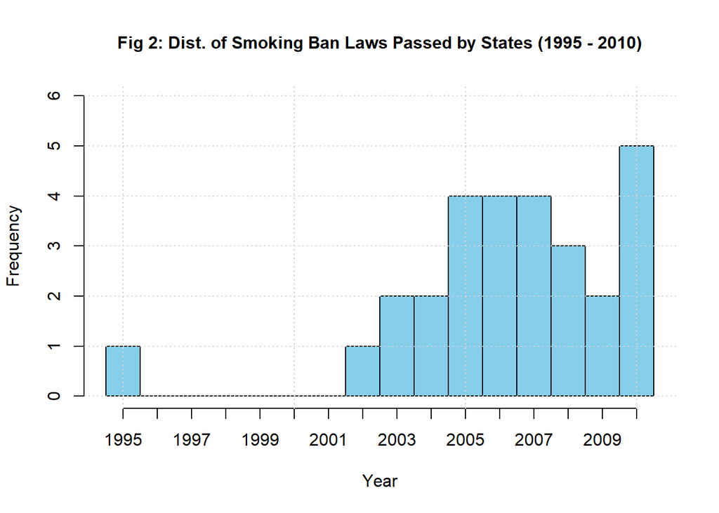

Figure 2 shows the distribution of states that passed smoking bans by year between 1995 to 2010. The graph shows that in 1995 only one state (California) had enacted a statewide smoking ban for restaurants. No other state enacted smoking bans from the period (1996 - 2001). After 2001 however, the pace of smoking ban laws seemed to have pickup. Increasing steadily from 2002 (Delaware) to a high in 2005-2007 when four states enacted smoking ban laws in each year. The growing pace seem to have fallen steadily again until 2009 when only two states enacted smoking bans. However, we see a huge jump in 2010 when five states enacted state smoking ban laws. This shows that majority of the states enacted smoking bans between the years 2002 and 2010.

```r
# Aggregate the data & calc. avg mortality rate for each state
agg_df <- aggregate(list(mortal_rate = sbl$mortal_rate), list(year = sbl$year), FUN = mean)
#agg_df <- aggregate(mortal_rate ~ year, data = sbl, FUN = mean)
#agg_df$year <- format(as.Date(agg_df$year, format = "%d-%b-%y"), "%Y")

# Scatterplot
plot(agg_df$year, agg_df$mortal_rate,
     main = "Fig:3 Distribution of Yearly Mortality Rate by State",
     cex.main = 1.0,
     xlab = "Year",
     ylab = "% Mortality Rate",
     pch = 19,
     col = "blue",
     xlim = c(1989, 2020),
     ylim = range(agg_df$mortal_rate))

lines(agg_df$year, agg_df$mortal_rate,
      type = "l",
      col = "tomato")

#axis(at = seq(1989, 2020, by = 5), las = 2)

# # Create bar plot
# barplot(agg_df$mortal_rate,
#         names.arg = agg_df$year,
#         main = "Distribution of Mortality Rate by Year",
#         xlab = "Year",
#         ylab = "Mortality Rate",
#         col = "skyblue",
#         border = "black",
#         ylim = c(0, max(agg_df$mortal_rate) + 5))

# Grid
grid()
```

**Plot**

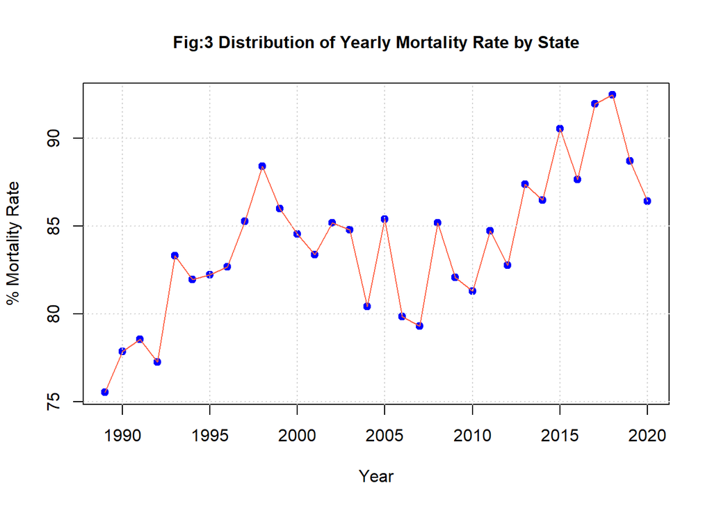

## Research Question:

The focus of this study is to study the effect of smoking bans on mortality rate, the following hypothesis will be tested”

Null Hypothesis (H0): The implementation of smoking bans has no effect on mortality rates associated with smoking-related diseases.

Alternative Hypothesis (H1): The implementation of smoking bans leads to a statistically significant change in mortality rates associated with smoking-related diseases compared to areas without such bans.

## Data Description:

The data utilized in this study covers the period from 1989 to 2020, and was compiled from various sources. Mortality rate data was obtained from the CDC Wonder database, collected on a state-by-state basis. This dataset includes information on mortality rates, population figures, median income levels, the percentage of college-educated individuals, median age demographics, and the political party affiliation of each state. Political party affiliation data specifically comprises the percentage of votes cast for the two major parties in the United States (Republican and Democrat). Additionally, information on the enactment years of “smoking ban laws” in states that implemented such laws between 1989 and 2020 was gathered for inclusion in the study.

## Summary Statistics:

```r
library(modelsummary)

datasummary_skim(sbl[c("mortal_rate", "m_age","m_income","p_colledu","population")], histogram = TRUE, title = "Table: 2 Summary Statistics")
```

|  | Unique | Missing Pct. | Mean | SD | Min | Median | Max |
| --- | --- | --- | --- | --- | --- | --- | --- |
| mortal_rate | 1632 | 0 | 84.0 | 17.0 | 27.0 | 83.0 | 149.7 |
| m_age | 163 | 0 | 36.0 | 3.0 | 25.4 | 36.2 | 45.1 |
| m_income | 1585 | 0 | 58976.6 | 9808.8 | 34916.0 | 58130.0 | 92266.0 |
| p_colledu | 324 | 0 | 26.5 | 6.6 | 11.1 | 25.8 | 63.6 |
| population | 1631 | 0 | 5735376.7 | 6446209.6 | 453541.0 | 3921093.0 | 39557045.0 |

The summary statistics for the dataset are presented here. Across all states included in the analysis, the maximum age observed was approximately 45 years, while the minimum age was 25 years. The mean age across states was 36 years, with a standard deviation of 3.0. The highest reported median income was approximately 92,266 USD, whilst the lowest was 34,916 USD. The average median income across states was 58,976 USD, with a standard deviation of 9,808. The maximum mortality rate recorded was 150 deaths per hundred thousand population, with the minimum being 27 deaths per hundred thousand population. The mean mortality rate across states was 84 deaths per hundred thousand population, with a standard deviation of 17 deaths per hundred thousand population. In terms of educational attainment, the maximum percentage of college-educated individuals in the states was 64, while the minimum was 11. The mean percentage of college-educated individuals was 27, with a standard deviation of 6.6. Subsequently, the paper proceeds to present a theoretical model examining the impact of smoking ban laws on mortality rates.

```r
##**The Relationship Between Smoking Ban Laws and Mortality Rates**

set.seed(757)

numer <- aggregate(list(mortality = sbl$mortal_rate0 * sbl$population),
          list(rel_time = sbl$rel_time_fake,
               treat = !is.na(sbl$treat_year)),
          sum, na.rm = TRUE)

denom <- aggregate(list(pop = sbl$population),
          list(rel_time = sbl$rel_time_fake,
               treat = !is.na(sbl$treat_year)),
          sum, na.rm = TRUE)

numer$mortality_rate <- numer$mortality/denom$pop
temp <- numer

# Find the mean of deaths grouped by rel_years and treat_state
agg <- aggregate((sbl$deaths/sbl$population)*100000, list(sbl$rel_time, sbl$treat), mean)

# Plot of DiD Curves
lim <- temp$rel_time %in% -3:3

plot(temp$rel_time[lim],
     temp$mortality_r[lim],
     las = 1,
     ylim = c(90,110),
     #xlim = c(-5, 5),
     main = "Fig: 4 Graph of Average Mortality Rate by years",
     type = "n",
     ylab = "Average Mortality Rate",
     xlab = " Years")

lines(temp$rel_time[temp$treat == 0 & lim],
     temp$mortality_rate[temp$treat == 0 & lim],
     lty = 1, pch = 4, type = "b")

lines(temp$rel_time[temp$treat == 1 & lim],
     temp$mortality_rate[temp$treat == 1 & lim],
     lty = 1, pch = 19, type = "b", col = "tomato")
abline(v = 0)
```

**Plot**

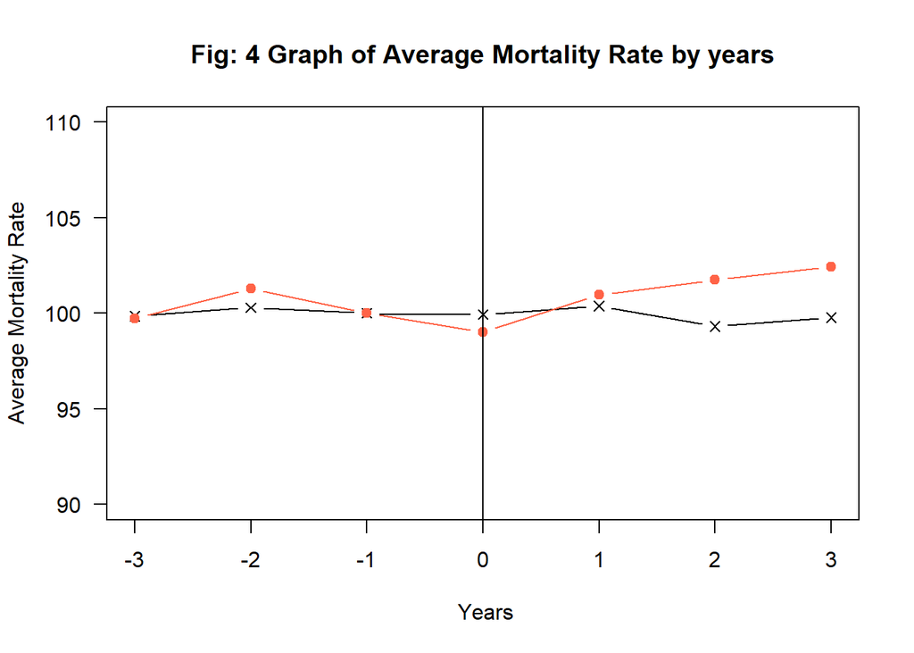

## Empirical Strategy:

To estimate the effect of smoking ban laws on mortality rate, I model a two way fixed-effects (TWFE) regression as presented below.

$$ln(Mortality\_Rate_{it}) = \beta_1SBL_{it} + \beta_2X_{it} + \alpha_i + \lambda_t + \epsilon_{it} \qquad \qquad (eqn_1)$$

The variables in the model are described as follows, $Mortality\_Rate_{it}$ represents the outcome or dependent variable (mortality rate per state in a given year) which our model seeks to predict. $SBL_{it}$ represents our independent variable (the implementation of smoking ban laws) for a given state in a given year. The parameter of interest $\beta_1$ captures the causal impact of variation in smoking ban law on mortality rate for a given state in a given year. The vector $X_{it}$ represents control variables such as median age, median income, percentage of population with college education among others. Also $\alpha_i$ and $\lambda_t$ represents state and year fixed effects respectively.

We control for median income in our model as there is a direct relationship between median income and health outcomes. It is presumed that regions with higher median income usually have better access to healthcare, healthier lifestyles, and improved living conditions. These regions are more likely to implement smoking bans which could lead to lower mortality rates. These regions may also have lower mortality rates due to other factors related to higher socioeconomic status. Not only this, but median income can also vary widely across different geographic areas, even within the same state. By including median income as a control variable, we are able to account for this spatial variability and better capture the nuanced relationship between smoking bans and mortality rates. Controlling for median income helps reduce the bias and ensure that the estimated effects of smoking bans are devoid of underlying socioeconomic differences between regions.

In addition, we control for college education a proxy for socioeconomic status. Populations with higher levels of educated individuals tend to have better access to resources including healthcare and as such are more likely to adopt healthier behaviors. Not only this, states with higher college-educated individuals may have lower mortality rates due to other socioeconomic factors such as stable employment opportunities, higher income levels, access to healthcare coverage and resources for maintaining good health. Also, educated individuals are more likely to have higher levels of health literacy and awareness about the risks of smoking. They are therefore more inclined to adopt healthier lifestyles. Further, college education may also interact with smoking bans in influencing mortality rates. For instance, the effectiveness of smoking bans in reducing mortality rates may vary among different educational levels. Controlling for college education enables us to explore potential interaction effects and examine whether the impact of smoking bans differs across various educational levels.

In our model we decide to weight our estimates by population for the following reasons. First by using population weights we ensure that the sample used in our analysis accurately depicts the demographic composition of the population. Weighting balances over representation in the analysis that could bias the outcome of our estimates. By weighting we are able to reduce sampling bias and account for variations in the size of different subgroups within the population. In effect we are able to generalize our findings beyond the sample to the broader population. Thus, assigning weights enables us to adjust for discrepancies and ensure that our estimates are representative of the entire population.

**TWFE Bias and Goodman-Bacon Analysis**:

The estimated coefficient of interest of the TWFE staggered treatment model often fails to capture expected estimates. This modeling challenge is often due to improper comparison of treatment and control groups at different points in time as treatment timing is staggered and treatment effects are heterogeneous. This may be due to such factors as spill over of earlier treatment to later periods, differences in implementation timing, improper comparison of treatment and control groups at different points in time. These challenges could result in biased estimates of the overall treatment effect.

Given that our model represents staggered implementation of smoking bans across different states over a period of time, coefficient from our TWFE model would be biased. To analyses the underlying cause of this bias, we employ Goodman-Bacon’s function to decomposing our TWFE model into individual components. Bacon’s function decomposes the TWFE model by isolating trends in the model as well as exposing interactions between the various control and treatment groups in the TWFE model.

**Two Stage Diff and Diff**:

$$(Mortality{\_}Rate_{it} - \hat\alpha_i + \hat\lambda_t) = \beta_1SBL_{it} + \beta_2X_{it} + \epsilon_{it} \qquad \qquad (eqn_3)$$

To address the TWFE challenge, we employ the two-stage difference-in-difference model proposed by Gardner (2022). Gardner proposed the removal of the state and year fixed effects estimates from our outcome variable so that the eventual regression is devoid of the bias. This is possible as the state and year fixed effects do not vary by time and as such all estimates yield the same results.

To do this, we first estimate our state and year fixed effects from the untreated time periods in our initial stage. We then subtract the unbiased estimated state and year fixed effects from our outcome variable (mortality rate). Finally, we fit the output of the first stage on the treatment variable without the fixed effects estimates.

Results from our estimates are presented in the next section.

## Results:

```r
##Output of TWFE Model

sbl$lmortal_rate <- log(sbl$mortal_rate)
sbl$lm_income <- log(sbl$m_income)

## Two Way Fixed Effects | no controls | unweighted
r0a <- fixest::feols(lmortal_rate ~ did | as.factor(state) + as.factor(year),
                     data = sbl)
#summary(r0a)

## Two Way Fixed Effects | no controls | weighted
r0b <- fixest::feols(lmortal_rate ~ did | as.factor(state) + as.factor(year),
                     data = sbl, weights = ~population)
#summary(r0b)

## Two Way Fixed Effects | with controls | weighted
r0c <- fixest::feols(lmortal_rate ~ did + m_age + lm_income + p_colledu |
                       state + year, data = sbl, weights = ~population)
#summary(r0c)


regz <- list(`2WFE | no Controls | unweighted` = r0a,
             `2WFE | no Controls | weighted*` = r0b,
             `2WFE | with Controls | weighted*` = r0c)

## Use modelsummary to output the results
coefz <- c("did" = "Smoking Ban Laws (SBL)",
           "year" = "Year Fixed Effect",
           "lmortal_rate" = "Log Mortality Rate",
           "state" = "State Fixed Effect",
           "population" = "Population",
           "(Intercept)" = "Constant")

gofz <- c("nobs", "r.squared")

modelsummary(regz,
             title = "Table 3: TWFE with State Model Smoking Ban laws and Mortality Rates",
             estimate = "{estimate}{stars}",
             coef_map = coefz,
             gof_map = gofz,
             notes = "*Weights are by population")
```

Table 3: TWFE with State Model Smoking Ban laws and Mortality Rates

|  | 2WFE \| no Controls \| unweighted | 2WFE \| no Controls \| weighted* | 2WFE \| with Controls \| weighted* |
| --- | --- | --- | --- |
| Smoking Ban Laws (SBL) | −0.062* | −0.045* | −0.052** |
|  | (0.027) | (0.022) | (0.019) |
| Num.Obs. | 1632 | 1632 | 1632 |
| R2 | 0.881 | 0.864 | 0.881 |

*Weights are by population

Table 3 above depicts the output of three TWFE models of the relationship between smoking ban laws and mortality rates. column one models a regression with no controls and unweighted. Column two’s represents a TWFE model with no controls but weighted. In column three the model has both controls and it is also weighted by the population of each state. Also standard errors for this estimates are clustered at the state level.

The analysis of column one reveals that the enactment of smoking ban laws is associated with a 6.2 percentage decrease in mortality rates, with statistical significance observed at the 5 percent level. The results derived from column two indicate that the implementation of smoking ban laws is linked to a 4.5 percent decrease in mortality rates, with statistical significance observed at the 5 percent level. Column three models a fixed effects regression where controls and weights are included to account for unobserved heterogeneity. The findings of this model indicate that the implementation of smoking ban laws resulted in a statistically significant reduction in mortality rates by 5.2 percent, with the significance observed at the 1 percent level.

In the next step we decompose the TWFE model, with the Goodman-Bacon function, into its component parts.

**Goodman-Bacon Decomposition:**

```r
cat("\n##### Goodman-Bacon Decomp #####\n")
bacondecomp::bacon(formula = lmortal_rate ~ did,
                                 id_var = "state",
                                 time_var= "year",
                                 data = sbl,
                                 quietly = FALSE)
```

| Type | Weight | Average_Estimate |
| --- | --- | --- |
| Earlier vs Later Treated | 0.08899 | −0.02067 |
| Later vs Earlier Treated | 0.08588 | 0.04167 |
| Treated vs Untreated | 0.82513 | −0.07763 |

The Goodman-Bacon decomposition analysis, illustrates the weighted average of all possible 2x2 Difference-in-Differences (DiD) configurations within the model. Decomposing the Two-Way Fixed Effects (TWFE) framework reveals three distinct configurations:

1. First, the “treated vs untreated” model, with a weight of 0.82513, shows a negative average estimate of -0.07763.
2. Second, the “earlier vs later treated” model, with a weight of 0.08899, shows a negative average estimate of -0.02067.
3. Lastly, the “later vs earlier treated” model, with a weight of 0.08588, shows a positive average estimate of 0.04167.

The decomposed TWFE exposes clear distinctions between reliable estimates (earlier vs later treated and treated vs untreated) and the flawed estimate (later vs earlier treated). This flaw arises due to the inclusion of a “control” group tainted by prior treatment. This is also evidenced by its positive average estimate compared to the negative estimates of other groups. Consequently, this tainted estimate reduces the magnitude of the coefficient of the variable of interest ($\delta^{DD}$).

Upon identifying this flaw, we proceed to re-estimate our model using the two-stage Difference-in-Differences framework in the next step. This model rectifies the issue by removing the state and year fixed effects from the outcome variable before estimating the coefficient ($\delta^{DD}$) in the model.

**Two Stage Diff in Diff**

```r
library(did2s)

r2 <- did2s::did2s(sbl,
                   yname = "lmortal_rate",
                   first_stage = ~ 0 | state + year,
                   second_stage = ~ did,
                   treatment = "did",
                   cluster_var = "state")
#r2

r3 <- did2s::did2s(sbl,
                   yname = "lmortal_rate",
                   first_stage = ~ 0 | state + year,
                   second_stage = ~ did,
                   treatment = "did",
                   weights = "population",
                   cluster_var = "state")
#r3

regz <- list(`Two Stage DiD no weights` = r2,
             `Two stage DiD with weights` = r3)

## Use modelsummary to output the results
coefz <- c("lmortal_rate" = "Log Mortality Rate",
           "did" = "Smoking Ban Laws (SBL)",
           "population" = "Population",
           "state" = "State Fixed Effect",
           "year" = "Year Fixed Effect",
           "(Intercept)" = "Constant")

gofz <- c("nobs", "r.squared")

modelsummary(regz,
             title = "Table 4: Two Stage Difference in Difference ",
             estimate = "{estimate}{stars}",
             coef_map = coefz,
             gof_map = gofz)
```

Table 4: Two Stage Difference in Difference

|  | Two Stage DiD no weights | Two stage DiD with weights |
| --- | --- | --- |
| Smoking Ban Laws (SBL) | −0.081** | −0.103** |
|  | (0.030) | (0.037) |
| Num.Obs. | 1632 | 1632 |
| R2 | 0.153 | 0.271 |

```r
library(fixest)

#Event Study Estimate for Two Way Fixed Effects (2WFE)

##
es1 <- feols(lmortal_rate ~ i(rel_time, treat, ref = c(-1, -10000))
             | state + year + sw0(state[year]), data = sbl)


## Event Study for 2WFE
par(mfrow = c(1,2))
iplot(es1[[1]], xlim = c(-10, 10))
iplot(es1[[2]], xlim = c(-10, 10))
par(mfrow = c(1,1))
```

**Plot**

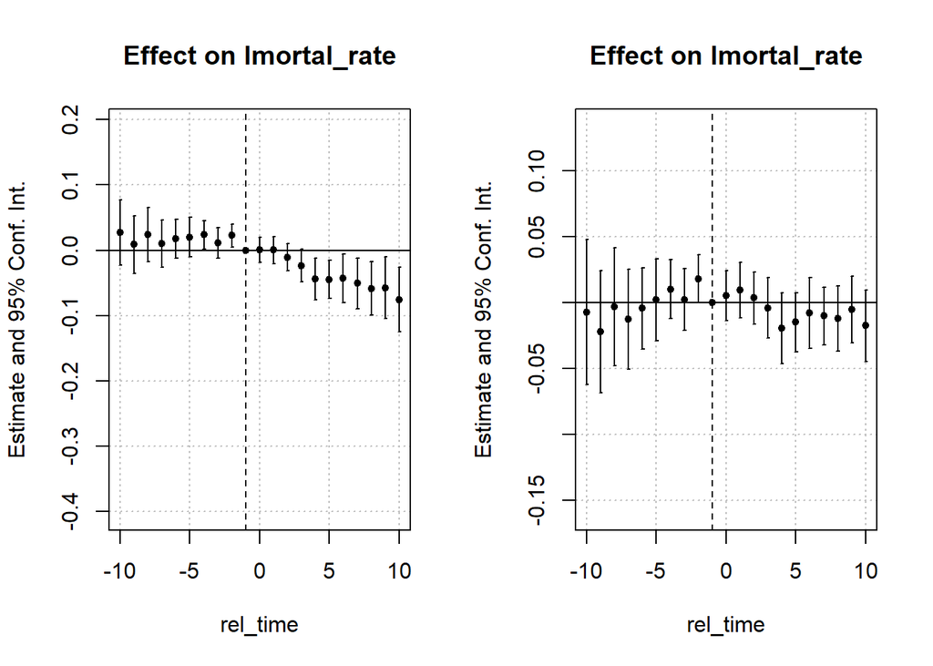

**Figure 4: Event Study of Effect of Smoking Ban Law on Mortality Rate:**

```r
library(fixest)

es2 <- did2s::did2s(sbl,
                   yname = "lmortal_rate",
                   first_stage = ~ 0 | state + year,
                   second_stage = ~ i(rel_time, ref = c(-1, -1000)),
                   treatment = "did",
                   cluster_var = "state")

es3 <- did2s::did2s(sbl,
                   yname = "lmortal_rate",
                   first_stage = ~ 0 | state + year,
                   second_stage = ~ i(rel_time, ref = c(-1, -1000)),
                   treatment = "did", weights = "population",
                   cluster_var = "state")


## Event Study for did2s
par(mfrow = c(1,2))
iplot(es2, xlim = c(-10, 10), main = "", col = "blue")
title(main = "A: Effect of SBL on Mortality Rate, no weights", cex.main = 0.8)
iplot(es3, xlim = c(-10, 10), main = "", col = "tomato")
title(main = "B: Effect of SBL on Mortality Rate, with weights", cex.main = 0.8)
par(cex.main = 0.1)
par(mfrow = c(1,1))
```

**Plot**

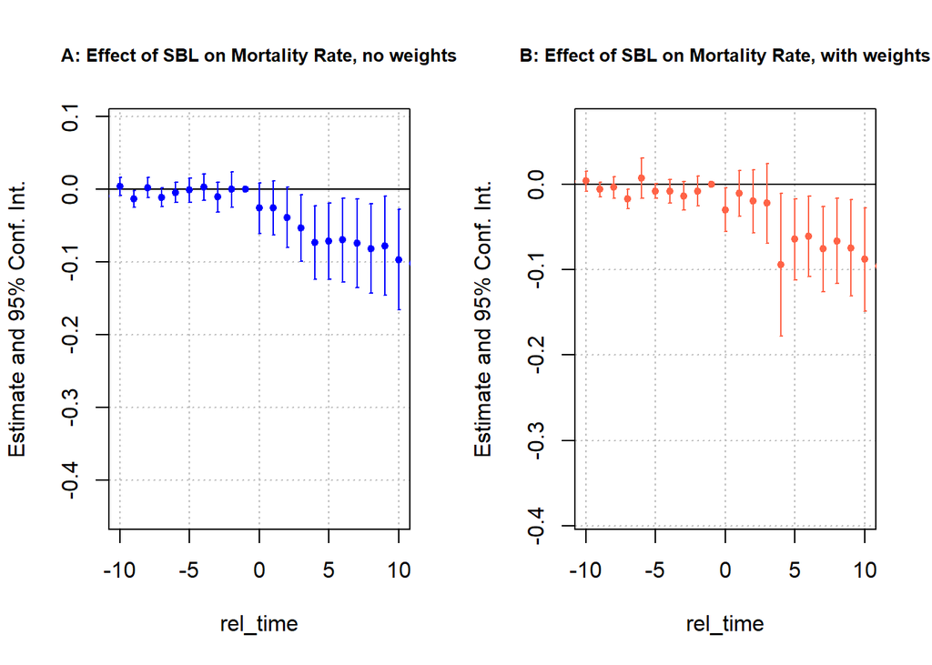

## Conclusion and Implications:

The goal of this study is to investigate the effect of the implementation of smoking ban laws on morality rates using a difference and difference analysis. A phenomenon that was started in California in 1995, smoking bans laws as of 2010 have been implemented in twenty eight states.

Results from this study confirms the negative association of smoking ban laws with mortality rates. Results from this study is comparable to other research findings. Gao *et al.* (2019) found an 8% decrease in the AMI mortality rate. Akter *et al.* (2023) found that smoke-free legislation was associated with approximately 9% to 10% cerebrovascular deaths (CVD).

## Appendix:

```r
library(modelsummary)

ban_yr <- read.csv("../data/res_states.csv")

# Rename the columns
names(ban_yr) <- c("State", "Year")

# Print the title
#cat("Table 1: Smoking Ban Laws enactment by State, 1995 - 2010:\n")

# Center justify the table and print
#print(format(ban_yr, justify = "center"))

datasummary_df(
  data = ban_yr,
  output = "default",
  align = "cc",
  title = "Table 1: Smoking Ban Laws Enactment by States, 1995 - 2010",
  notes = "https://www.cdc.gov/tobacco/data_statistics/mmwrs/index.htm "
)
```

Table 1: Smoking Ban Laws Enactment by States, 1995 - 2010

| State | Year |
| --- | --- |
| Arizona | 1-May-07 |
| California | 1-Jan-95 |
| Colorado | 1-Jul-06 |
| Connecticut | 1-Oct-03 |
| Delaware | 1-Nov-02 |
| Hawaii | 16-Nov-06 |
| Illinois | 1-Jan-08 |
| Iowa | 1-Jul-08 |
| Kansas | 1-Jul-10 |
| Maine | 1-Jan-04 |
| Maryland | 1-Feb-08 |
| Massachusetts | 1-Jul-04 |
| Michigan | 1-May-10 |
| Minnesota | 1-Oct-07 |
| Montana | 1-Oct-05 |
| Nebraska | 1-Jun-09 |
| New Jersey | 15-Apr-06 |
| New Mexico | 15-Jun-07 |
| New York | 24-Jul-03 |
| North Dakota | 2-Jan-10 |
| Ohio | 7-Dec-06 |
| Oregon | 1-Jan-09 |
| Rhode Island | 1-Mar-05 |
| South Dakota | 10-Nov-10 |
| Utah | 1-Jan-07 |
| Vermont | 1-Sep-05 |
| Washington | 8-Dec-05 |
| Wisconsin | 5-Jul-10 |

https://www.cdc.gov/tobacco/data_statistics/mmwrs/index.htm

## References

*270towin with urldate*, no date. (online: https://www.270towin.com/content/features-of-the-historical-interactive-maps).

Aggarwal, S., Attaway, A., Papani, R., Velani, S., Melgar, T., 2014. IMPACT OF SMOKING BAN ON CARDIOVASCULAR MORBIDITY AND MORTALITY: LESSONS TO LEARN FROM MICHIGAN, *Journal of the American College of Cardiology*, Elsevier BV, 63, 12, A1429. doi: 10.1016/s0735-1097(14)61429-7.

Akter, S., Islam, Md. R., Rahman, Md. M., Rouyard, T., Nsashiyi, R. S., Hossain, F., Nakamura, R., 2023. Evaluation of population-level tobacco control interventions and health outcomes: A systematic review and meta-analysis, *JAMA Network Open*, American Medical Association (AMA), 6, 7, e2322341. doi: 10.1001/jamanetworkopen.2023.22341.

Bose, S., Gebremedhin, T., 2015. Determining the variations in u.s. State-level mortality rate: A spatial durbin panel approach, *SSRN Electronic Journal*, Elsevier BV. doi: 10.2139/ssrn.2595435.

Carro, J. M., Traferri, A., 2012. STATE DEPENDENCE AND HETEROGENEITY IN HEALTH USING a BIAS‐CORRECTED FIXED‐EFFECTS ESTIMATOR, *Journal of Applied Econometrics*, Wiley, 29, 2, 181–207. doi: 10.1002/jae.2301.

*CDC wonder with urldate*, no date a. (online: https://www.cdc.gov/tobacco/data_statistics/fact_sheets/adult_data/cig_smoking/index.htm).

*CDC wonder with urldate*, no date b. (online: https://www.cdc.gov/tobacco/data_statistics/mmwrs/index.htm).

*CDC wonder with urldate*, no date c. (online: https://wonder.cdc.gov/controller/saved/D16/D383F490).

*CDC wonder with urldate*, no date d. (online: https://wonder.cdc.gov/controller/saved/D76/D383F493).

*CDC wonder with urldate*, no date e. (online: https://wonder.cdc.gov/controller/saved/D176/D383F495).

Cebula, R. J., Angjellari-Dajci, F., Kashian, R., 2015. Are there interregional differences in the response of cigarette smoking to state cigarette excise taxes in the USA? Exploratory analysis, *Journal of Applied Statistics*, Informa UK Limited, 43, 8, 1494–1507. doi: 10.1080/02664763.2015.1106451.

Fox, A. M., Feng, W., Yumkham, R., 2017. State political ideology, policies and health behaviors: The case of tobacco, *Social Science &amp; Medicine*, Elsevier BV, 181, 139–147. doi: 10.1016/j.socscimed.2017.03.056.

Fujikake, A., Komatsu, T., Nakahara, S., Taguchi, I., 2016. Impact of legislation for smoking cessation and the tokyo olympic and paralympic games 2020, *Circulation Journal*, Japanese Circulation Society, 80, 12, 2432–2434. doi: 10.1253/circj.cj-16-1074.

Gao, M., Li, Y., Wang, F., Zhang, S., Qu, Z., Wan, X., Wang, X., Yang, J., Tian, D., Zhang, W., 2019. The effect of smoke-free legislation on the mortality rate of acute myocardial infarction: A meta-analysis, *BMC Public Health*, Springer Science; Business Media LLC, 19, 1. doi: 10.1186/s12889-019-7408-7.

Gardner, J., 2022. Two-stage differences in differences, arXiv. doi: 10.48550/ARXIV.2207.05943.

Mueller, P. S., Facp., 2014. Smoking bans are associated with mortality benefits among the incarcerated, *NEJM Journal Watch*, 2014. (online: https://api.semanticscholar.org/CorpusID:154330902).

Zhang, J., 2018. Prison smoking bans in the united states: Current policy, impact and obstacle, *Journal of Hospital Management and Health Policy*, AME Publishing Company, 2, 20–20. doi: 10.21037/jhmhp.2018.04.06.